# Part 1: exponential distribution

Swathi Vijayakumar

August 23, 2015

In purpose of part 1 is to investigate the exponential distribution in R and compare it with the Central Limit Theorem. The exponential distribution will be simulated in R with rexp(n, lambda) where lambda is the rate parameter. The mean of exponential distribution is 1/lambda and the standard deviation is also 1/lambda. We will set lambda = 0.2 for all of the simulations and investigate the distribution of averages of 40 exponentials. At least a thousand simulations will be performed.

### 1. Show the sample mean and compare it to the theoretical mean of the distribution.

```r
library(stats)
n = 40
nosim = 1:1000
set.seed(5)
lam = 0.2
dat = data.frame(exp_dist = sapply(nosim,function(x){mean(rexp(n,lam))}))
```

**first calculate the mean of the exponential distribution**

```r
samp_mean = mean(dat$exp_dist)
round(samp_mean,3)
```

```
## [1] 5.043
```

we are told that the mean of the exponential distribution is 1/lambda

```r
round(1/lam,3)
```

```
## [1] 5
```

As shown above the actual center of the distribution 5.043 is close to the thoretical center of the distribution 5.

### 2. Show how variable the sample is (via variance) and compare it to the theoretical variance of the distribution.

**Calculate the standard deviation of the exponential distribution using the sd function**

```r
sd = sd(dat$exp_dist)
round(sd,3)
```

```
## [1] 0.776
```

The theoretical standard deviation is

```r
round((1/lam)/sqrt(40),3)
```

```
## [1] 0.791
```

**Calculate the variance of the exponential distribution using the var function**

```r
samp_var = var(dat$exp_dist)
round(samp_var,3)
```

```
## [1] 0.603
```

we are told that the standard deviation is 1/lambda. The theoretical Variance is sigma^2/n where sigma is the standard deviation

```r
round(((1/lam)^2)/n,3)
```

```
## [1] 0.625
```

As shown above the actual variance 0.603 is close to the thoretical variance of 0.625.

### 3. Show that the distribution is approximately normal.

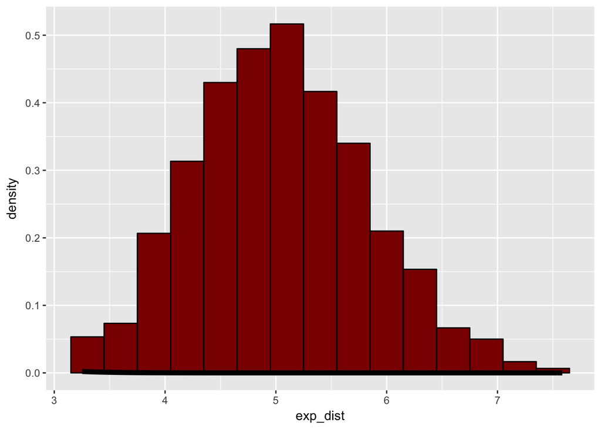

```r
library(ggplot2)
g = ggplot(dat, aes(x=exp_dist)) + geom_histogram(binwidth=.3,color = "black",fill = "darkred",aes(y=..density..))
g = g + stat_function(fun=dnorm,arg = list(mean = 5,sd = sd(dat$exp_dist)),size=2, warning=FALSE)
g
```